# Final Project

박찬영

2024-11-22

```r
library(tidyverse)
```

```r
wd <- paste0(getwd(), "\\R\\2024\\FinalProject\\")
scf <- read_csv(paste0(wd, "scf_data.csv"))
scorecard <- read_csv(paste0(wd, "scorecard.csv"))
```

## Topic 1 : College Scorecard data

`scorecard.csv`는 미국 교육부에서 제공하는 College Scorecard 의 교육기관별 데이터이다. College Scorecard 데이터는 각 대학의 분류, 학생지원, 학생들의 성과 등에 대한 정보를 제공한다. 이 데이터셋은 6484개의 대학과 3305개의 변수로 이루어져 있다.

주요 변수와 대략적인 설명은 아래와 같다. (자세한 설명은 https://collegescorecard.ed.gov의 Data Dictionary에서 확인할 수 있다.)

- `UNITID` : 대학의 고유 식별번호
- `INSTNM` : 대학의 이름
- `STABBR` : state 코드 (eg. AL: Alabama, CA: California, NY: New York)
- `PREDDEG` : 대학이 수여하는 주요 학위 (`0`:미분류, `1`:자격증, `2`:준학사, `3`:학사, `4`:대학원)
- `UGDS` : 학부 학생 수
- `ADM_RATE` : 입학률(입학을 허가받은 학생 수 / 지원한 학생 수)
- `MD_EARN_WNE_P6` : 입학 후 6년 뒤 급여의 중위값
- `PCT(25/75)_EARN_WNE_P6` : 입학 후 6년 뒤 급여의 (25/75) 백분위수 (eg. `PCT25_EARN_WNE_P6`)
- `DEBT_MDN` : 상환집단(상환을 시작한 학생) 중 대출 원금의 중위값
- `RPY_5YR_RT` : 상환집단 중 채무불이행 없이 5년간 대출 상환을 유지한 비율
- `FAMINC` : 입학 시 가구소득의 평균값

#### * 본 분석에는 학부 학생 수가 800명 이상, 입학률이 0 초과, 수여하는 주요 학위가 학사학위인 대학만을 사용한다. 아래의 기준에 따라 데이터 전처리를 진행하고, `data_cs`로 저장하시오. [2점]

- `UNITID`, `INSTNM`, `STABBR`은 character 변수로 저장한다.
- `PREDDEG` 변수는 factor형 변수로 저장한다.
- 이외의 주요 변수는 numeric 변수로 저장하되, 값 ’PS’는 결측(NA)으로 처리한다.
- 학부 학생 수가 800명 이상, 입학률이 0 초과, 수여하는 주요 학위가 학사학위인 대학을 추출한다.

```r
data_cs <- scorecard %>%
  select(
    UNITID, INSTNM, STABBR, PREDDEG, UGDS, ADM_RATE, MD_EARN_WNE_P6,
    PCT25_EARN_WNE_P6, PCT75_EARN_WNE_P6, DEBT_MDN, RPY_5YR_RT, FAMINC
  ) %>%
  mutate(UNITID = as.character(UNITID), PREDDEG = as.factor(PREDDEG)) %>%
  mutate(across(c(10, 11, 12), ~parse_number(., na = c("PS", "NA")))) %>%
  filter(UGDS >= 800, ADM_RATE > 0, PREDDEG == 3)

glimpse(data_cs)
```

```
## Rows: 1,237
## Columns: 12
## $ UNITID            <chr> "100654", "100663", "100706", "100724", "100751", "1…
## $ INSTNM            <chr> "Alabama A & M University", "University of Alabama a…
## $ STABBR            <chr> "AL", "AL", "AL", "AL", "AL", "AL", "AL", "AL", "AL"…
## $ PREDDEG           <fct> 3, 3, 3, 3, 3, 3, 3, 3, 3, 3, 3, 3, 3, 3, 3, 3, 3, 3…
## $ UGDS              <dbl> 5196, 12776, 6985, 3296, 31360, 3307, 25234, 968, 15…
## $ ADM_RATE          <dbl> 0.6840, 0.8668, 0.7810, 0.9660, 0.8006, 0.9223, 0.43…
## $ MD_EARN_WNE_P6    <dbl> 27851, 46572, 55610, 27453, 52233, 38216, 54629, 452…
## $ PCT25_EARN_WNE_P6 <dbl> 14130, 29464, 33999, 15271, 33353, 22285, 36022, 272…
## $ PCT75_EARN_WNE_P6 <dbl> 44543, 66959, 81066, 40900, 75004, 55734, 74667, 605…
## $ DEBT_MDN          <dbl> 16600, 15832, 13905, 17500, 17986, 13119, 17750, 160…
## $ RPY_5YR_RT        <dbl> 0.3311258, 0.5710578, 0.5883111, 0.2897054, 0.635813…
## $ FAMINC            <dbl> 32362.83, 51306.67, 61096.59, 31684.38, 91846.75, 41…
```

#### **Question 1. (Admission rate) [15점]**

**각 대학의 입학률(경쟁률)에 대해 살펴보고자 한다. 아래 물음에 답하시오.**

1. 입학률을 기준으로, 경쟁률이 가장 높은 상위 15개 대학을 출력하시오. [2점]

```r
data_cs %>%
  arrange(ADM_RATE) %>%
  head(15)
```

```
## # A tibble: 15 × 12
##    UNITID INSTNM  STABBR PREDDEG  UGDS ADM_RATE MD_EARN_WNE_P6 PCT25_EARN_WNE_P6
##    <chr>  <chr>   <chr>  <fct>   <dbl>    <dbl>          <dbl>             <dbl>
##  1 110404 Califo… CA     3         982   0.0269         132140             68345
##  2 166027 Harvar… MA     3        7973   0.0324          99572             54333
##  3 243744 Stanfo… CA     3        7761   0.0368         102887             64169
##  4 190150 Columb… NY     3        8902   0.0395          88535             48134
##  5 166683 Massac… MA     3        4638   0.0396         131633             93246
##  6 130794 Yale U… CT     3        6639   0.0457          81765             52868
##  7 217156 Brown … RI     3        7222   0.0506          79131             46303
##  8 144050 Univer… IL     3        7511   0.0543          80870             48014
##  9 186131 Prince… NJ     3        5527   0.057           87815             52741
## 10 198419 Duke U… NC     3        6570   0.0635          85792             55723
## 11 182670 Dartmo… NH     3        4412   0.0638          82541             46267
## 12 215062 Univer… PA     3       10572   0.065           90555             55424
## 13 221999 Vander… TN     3        7144   0.0667          73909             49418
## 14 167358 Northe… MA     3       16172   0.068           78413             52640
## 15 216287 Swarth… PA     3        1619   0.0693          56211             32936
## # ℹ 4 more variables: PCT75_EARN_WNE_P6 <dbl>, DEBT_MDN <dbl>,
## #   RPY_5YR_RT <dbl>, FAMINC <dbl>
```

2. 대학이 가장 많이 소재한 상위 3개 주(state)를 출력하시오. [2점]

```r
data_cs %>%
  count(STABBR, sort = TRUE) %>%
  head(3)
```

```
## # A tibble: 3 × 2
##   STABBR     n
##   <chr>  <int>
## 1 NY       102
## 2 PA        91
## 3 CA        73
```

3. 입학률이 0.3 이하인 대학을 ’명문(prestigious)대학’으로 정의한다. 명문대학이 가장 많이 소재한 상위 3개 주(state)를 출력하시오. [2점]

```r
data_cs %>%
  filter(ADM_RATE <= 0.3) %>%
  count(STABBR, sort = TRUE) %>%
  head(3)
```

```
## # A tibble: 3 × 2
##   STABBR     n
##   <chr>  <int>
## 1 CA        14
## 2 NY        12
## 3 MA        11
```

4. 캘리포니아에 위치한 명문대학의 이름을 모두 출력하시오. [2점]

```r
data_cs %>%
  filter(ADM_RATE <= 0.3, STABBR == "CA") %>%
  select(INSTNM)
```

```
## # A tibble: 14 × 1
##    INSTNM
##    <chr>
##  1 California Institute of Technology
##  2 University of California-Berkeley
##  3 University of California-Irvine
##  4 University of California-Los Angeles
##  5 University of California-San Diego
##  6 University of California-Santa Barbara
##  7 California Institute of the Arts
##  8 Claremont McKenna College
##  9 Harvey Mudd College
## 10 Pitzer College
## 11 Pomona College
## 12 Scripps College
## 13 University of Southern California
## 14 Stanford University
```

5. `ggplot2` 패키지의 `map_data('state')`는 미국의 각 주(state)에 대한 위도와 경도를 제공한다. 소재한 명문대학의 수가 3개 이상인 주에 대해서 명문대학의 수를 표시한 지도를 그리시오. (주어진 그래프는 일부에 대한 예시이다.) [7점]
- 주의 이름과 약어는 기본 패키지의 `state.name`과 `state.abb`을 참고한다. (Hint : Use `state_name = data.frame(region = state.name %>% tolower(), STABBR = state.abb)`)
- 주의 중심점은 위도와 경도 각각의 최대값과 최소값의 평균으로 간주한다.
- `map_data('state')`내 미국의 모든 주는 검은 선과 흰색 바탕으로 그린다. (Hint : Use `geom_polygon(aes(group=group))`)
- 해당 주를 지도 상의 색으로 표시하고 중심점에 명문대학의 수를 표기한다. (단, `label` 값을 직접 입력하는 경우 점수 미부여)
- 위도와 경도의 눈금 및 텍스트는 표시하지 않는다. (Hint : Use `theme(axis.ticks, axis.line, axis.text, axis.title)`)
- 그래프의 비율은 `coord_fixed(1.3)`을 이용한다.

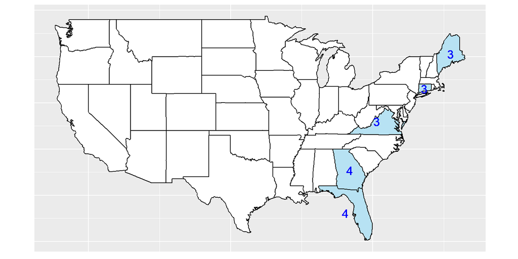

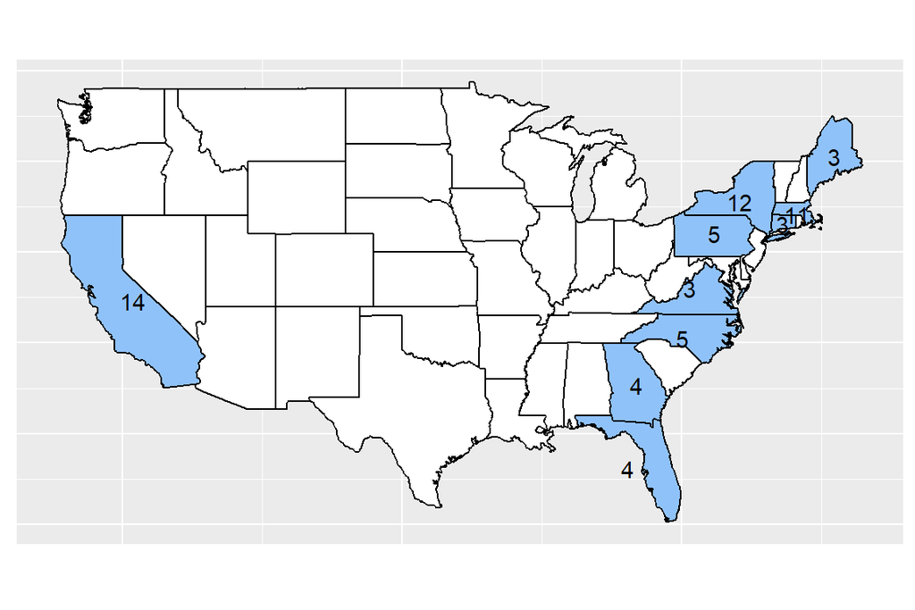

```r
namedoor <- data_cs %>%
  filter(ADM_RATE <= 0.3) %>%
  count(STABBR, sort = TRUE) %>%
  filter(n >= 3)

state_name <- data.frame(region = state.name %>% tolower(), STABBR = state.abb)

namedoor_map <- map_data("state") %>%
  inner_join(left_join(namedoor, state_name, by = "STABBR"), by = "region")

center <- namedoor_map %>%
  group_by(region) %>%
  summarise(
    long = mean(c(max(long), min(long))),
    lat = mean(c(max(lat), min(lat))),
    n = first(n)
  )


map_data("state") %>%
  ggplot() +
  geom_polygon(
    data = map_data("state"),
    aes(x = long, y = lat, group = group),
    fill = "white", color = "black"
  ) +
  geom_polygon(
    data = namedoor_map,
    aes(x = long, y = lat, group = group),
    fill = "#90c2fa", color = "black"
  ) +
  geom_text(data = center, aes(x = long, y = lat, label = n)) +
  theme(
    axis.ticks = element_blank(),
    axis.line = element_blank(),
    axis.title = element_blank(),
    axis.text = element_blank()
  ) +
  coord_fixed(1.3)
```

#### **Question 2. (Admission rate and Earnings) [13점]**

**입학률과 학생들의 (입학 후 6년 뒤) 급여의 관계를 확인해보고자 한다. 아래 물음에 답하시오.**

1. 입학률과 급여 중위값의 산점도를 그리시오. 두 변수 간에는 어떠한 관계가 있는가? [3점]

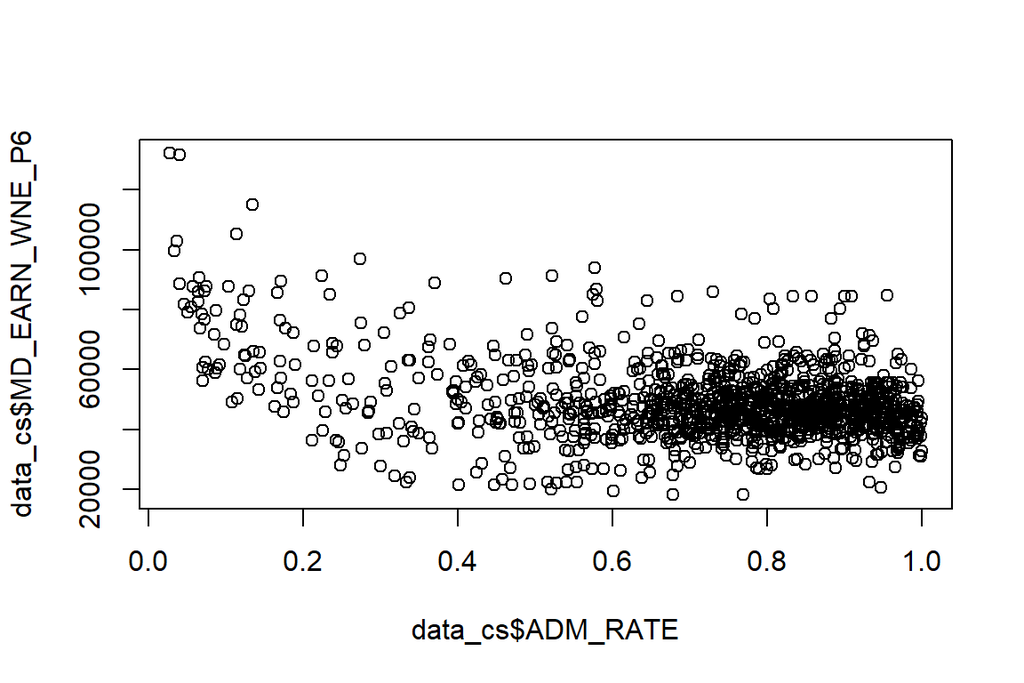

```r
plot(data_cs$ADM_RATE, data_cs$MD_EARN_WNE_P6)
```

아주 약한 음의 상관관계를 보이는 것 같다.

2. 입학률과 급여 중위값의 산점도를 명문대학과 비명문대학으로 구분하여 그리시오. 두 산점도에 어떠한 차이가 나타나는가? [3점]

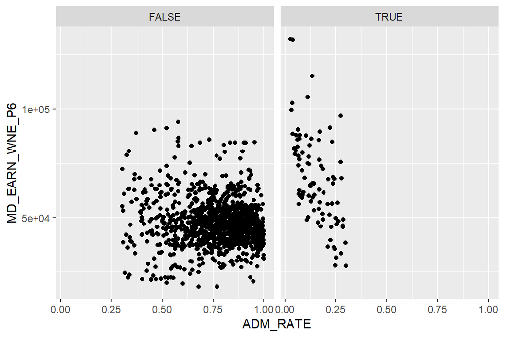

```r
data_cs %>%
  mutate(namedoor = (ADM_RATE <= 0.3)) %>%
  ggplot(aes(ADM_RATE, MD_EARN_WNE_P6)) +
  geom_point() +
  facet_wrap(~namedoor)
```

명문대는 비명문대보다 음의 상관관계가 더 잘 보인다.

3. Ivy League 대학에 대해, 아래의 기준에 따라 급여의 분포를 비교하는 boxplot을 그리시오. (주어진 그래프는 일부에 대한 예시이다.) [7점]
- Ivy League는 8개 대학 Brown University, Columbia University, Cornell University, Dartmouth College, Harvard University, University of Pennsylvania, Princeton University, Yale University를 말한다.
- 급여의 사분위수를 box로 표시한다. (Hint : Use `geom_boxplot(mapping=aes(), stat='identity')`)
- 급여의 중위값 내림차순으로 그리며, 해당 대학의 급여 중위값($)을 해당 경계 옆에 표기한다.
- x축은 30000부터 180000까지 30000 단위로 표시하며, y축은 각 대학의 이름과 해당 대학의 ADM_RATE 순위를 [대학 이름 (순위)] 형태로 병기한다.
- 그래프의 제목은 `Quantile Earnings 6 Years after Entry ($)’이고, x축과 y축의 이름은 표시하지 않는다. 그래프의 색상 등은 가시성 있게 적절히 선택한다.
- 단, 대학의 이름은 위에 제시된 형태로 표기되어야 하며, 정규표현식을 활용하여 데이터 내의 표기형태를 찾을 수 있다.

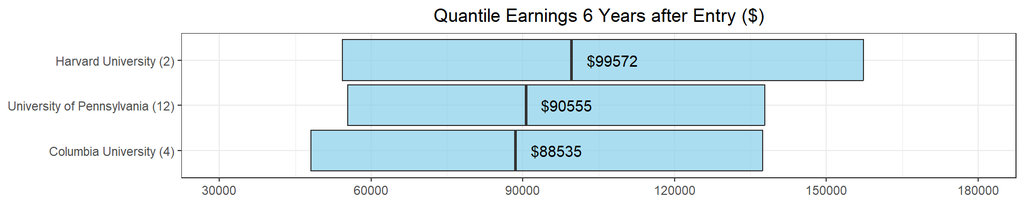

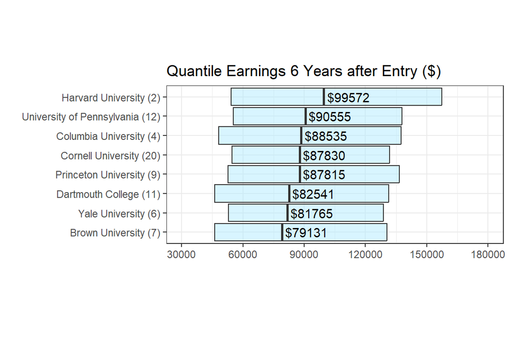

```r
ivyl <- c(
  "Brown University",
  "Columbia University in the City of New York",
  "Cornell University",
  "Dartmouth College",
  "Harvard University",
  "University of Pennsylvania",
  "Princeton University",
  "Yale University"
)



data_cs %>%
  mutate(rank = rank(ADM_RATE)) %>%
  filter(INSTNM %in% ivyl) %>%
  mutate(INSTNM = as.factor(str_replace_all(
    INSTNM,
    "Columbia University in the City of New York",
    "Columbia University"
  ))) %>%
  mutate(INSTNM = paste0(INSTNM, " (", rank, ")")) %>%
  mutate(INSTNM = fct_reorder(as.factor(INSTNM), MD_EARN_WNE_P6)) %>%
  ggplot(aes(x = INSTNM)) +
  geom_boxplot(aes(
    ymin = PCT25_EARN_WNE_P6,
    ymax = PCT75_EARN_WNE_P6,
    lower = PCT25_EARN_WNE_P6,
    middle = MD_EARN_WNE_P6,
    upper = PCT75_EARN_WNE_P6
  ), stat = "identity", fill = "#b1ebff", alpha = 0.5) +
  geom_text(
    aes(y = MD_EARN_WNE_P6 + 12000, label = paste0("$", MD_EARN_WNE_P6))
  ) +
  scale_y_continuous(
    limits = c(30000, 180000),
    breaks = seq(30000, 180000, 30000)
  ) +
  labs(
    title = "Quantile Earnings 6 Years after Entry ($)",
    y = "",
    x = ""
  ) +
  theme_bw() +
  theme(aspect.ratio = 0.47) +
  coord_flip()
```

#### **Question 3. (Debt and Repayment) [10점]**

**상환집단의 대출 원금(중위값)과 (5년 간) 상환 유지 비율의 관계를 확인하고자 한다. 물음에 답하시오.**

1. 일반적으로 대출 원금이 낮다면 채무불이행 없이 대출상환을 꾸준히 유지하기 쉽다. 대출 원금과 상환 유지 비율의 산점도와 추세선을 그리고 결과를 해석하시오. [3점]
- 단, 추세선은 선형추세 `method = 'lm'`을 사용한다.

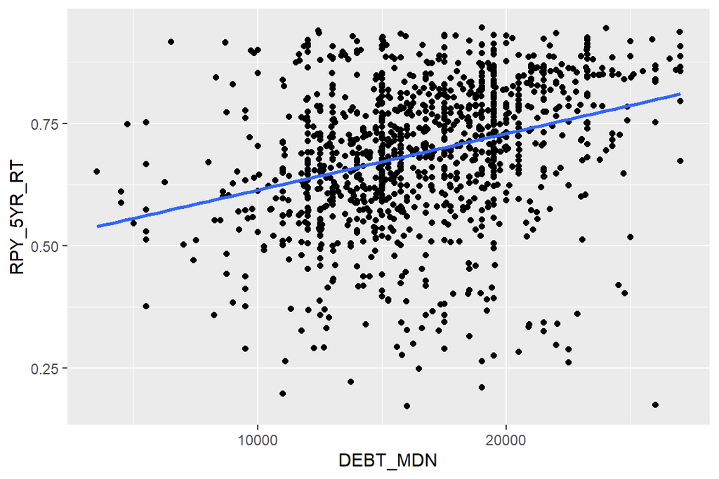

```r
data_cs %>%
  ggplot(aes(DEBT_MDN, RPY_5YR_RT)) +
  geom_point() +
  geom_smooth(method = "lm", se = FALSE)
```

어느정도 약한 양의 상관관계는 보이는 것 같다. 원금이 클수록 대출상환 유지비율이 크다는 것인데, 이는 예상과 다른 결과이다. 심슨의 역설일 수 있다.

2. 입학 시 평균 가구소득의 4분위수를 기준점으로 대학을 네 그룹으로 분류한 가구소득 그룹 `FAMINC_GR`을 정의한다. 대출 원금과 상환 유지 비율의 산점도와 추세선을 가구소득 그룹에 따라 색으로 구분하여 그리시오. 어떤 관계가 나타나는가? [3점]
- 추세선은 선형추세 `method = 'lm'`을 사용한다.
- 그룹이 NA인 대학은 제외한다.

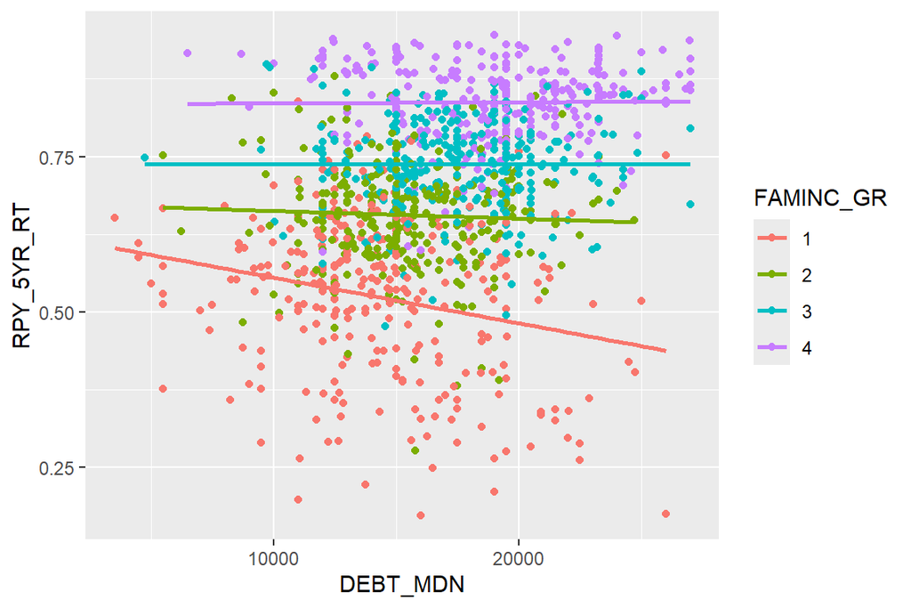

```r
new_data_cs <- data_cs %>%
  filter(!is.na(FAMINC)) %>%
  mutate(FAMINC_GR = cut(
    FAMINC,
    breaks = quantile(FAMINC, c(0, 0.25, 0.5, 0.75, 1)) - c(5, 0, 0, 0, 0),
    labels = c("1", "2", "3", "4")
  ))
new_data_cs %>%
  ggplot(aes(DEBT_MDN, RPY_5YR_RT, color = FAMINC_GR)) +
  geom_point() +
  geom_smooth(method = "lm", se = FALSE)
```

첫 예상대로 평균 가구소득이 중앙값보다 작은 두 그룹은 음의 상관관계를 보인다. 중앙값보다 큰 두 그룹은 상관관계를 거의 보이지 않는다. 심슨의 역설이 맞다. 또한 가구소득이 높을수록 대출상환율이 더 높다.

3. 중위 급여의 중위값을 기준점으로 대학을 두 그룹으로 분류한 급여 그룹 MD_EARN_WNE_P6_GR을 정의한다. facet_wrap()을 이용하여 각 가구소득 그룹에 대해, 대출 원금과 상환 유지 비율의 산점도와 추세선을 급여 그룹에 따라 색으로 구분하여 그리시오. 급여 그룹에 따른 분류로 어떠한 변화를 확인할 수 있는가? [4점]
- 추세선은 선형추세 `method = 'lm'`을 사용한다.
- 그룹이 NA인 대학은 제외한다.

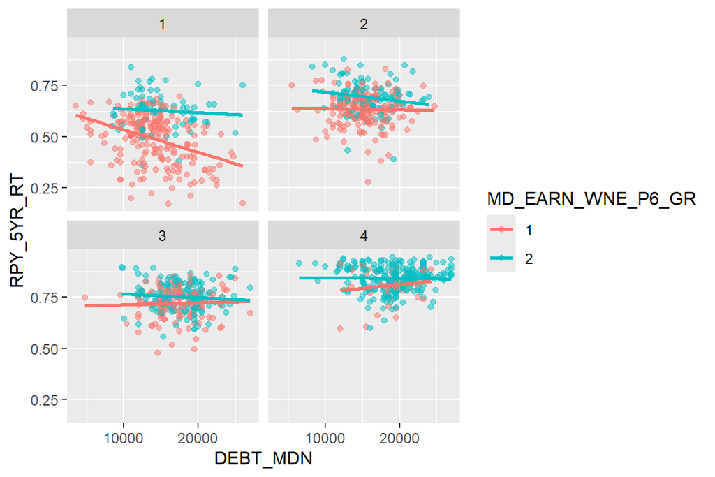

```r
new_data_cs %>%
  filter(!is.na(MD_EARN_WNE_P6)) %>%
  mutate(MD_EARN_WNE_P6_GR = as.factor(ifelse(
    MD_EARN_WNE_P6 > median(MD_EARN_WNE_P6),
    "2",
    "1"
  ))) %>%
  ggplot(aes(DEBT_MDN, RPY_5YR_RT, color = MD_EARN_WNE_P6_GR)) +
  geom_point(alpha = 0.5) +
  geom_smooth(method = "lm", se = FALSE) +
  facet_wrap(~FAMINC_GR)
```

모든 가구소득 그룹에서 급여 중위값이 중앙값보다 크면 대출상환율이 더 크다. 급여가 높은 그룹은 가구소득이 1분위일때보다 2분위일때 더 상환을 못하는 추세를 보이고, 급여가 낮은 그룹은 1분위일때가 2분위일때보다 더 상환을 못하는 추세를 보인다. 또 가구소득 1분위이고 급여가 낮은 그룹외에는 음의 상관관계가 뚜렷하게 보이는 그룹은 많지 않다. 처음의 예측은 가구소득과 6년뒤 급여가 낮은 사람들에 대해서 적중한다. 나머지 그룹에 대해서는 확신할 수 없다. 가구소득이 클수록 6년뒤 급여가 큰 데이터가 많아지는 사실도 어느정도 확인할 수 있다.

## Topic2 : 911 calls

Montgomery County in Pennsylvania의 911 calls (emergency calls) 에 대해 분석하고자 한다.

- `lat` : 위도(latitude)
- `lng` : 경도(longitude)
- `desc` : Description. Call에 대한 정보
- `zip` : zip 코드
- `title` : Call의 유형
- `timeStamp` : Call이 들어 온 시간
- `twp` : Township. County 내부 도시명
- `addr` : 상세 주소

#### **Question 4. Dataset을 부르고, 다음 문제에 대한 코드를 작성하시오. (총 15점)**

1. `e` 변수가 제거 가능한 근거를 제시하고 제거하시오.  
   또한 결측치가 있는 observation을 모두 제거하시오. (2점)

```r
nine11 <- read_csv("F:\\data\\911.csv")
summary(nine11$e)
```

```
##    Min. 1st Qu.  Median    Mean 3rd Qu.    Max.
##       1       1       1       1       1       1
```

```r
sum(is.na(nine11$e))
```

```
## [1] 0
```

```r
nine11_a <- nine11 %>% select(-e) %>% na.omit()
colSums(is.na(nine11_a))
```

```
##       lat       lng      desc       zip     title timeStamp       twp      addr
##         0         0         0         0         0         0         0         0
```

`e` 변수는 모든 값이 1인 변수이다. 이는 다른 관측치와 어떠한 관계나 영향 정보도주지 않아 삭제해도 된다.  
그리고 NA값을 모두 제거하였다.

2. `title` 변수에는 emergency calls의 종류(`type`)와 상세 사유(`type_detail`)가 기록되어 있다. `title` 변수를 `:`을 기준으로 `type`, `type_detail`로 분리하시오. 또한 `type`의 종류별 observation 개수를 table로 제시하시오. (3점)

```r
nine11_b <- nine11_a %>%
  separate_wider_delim(title, ": ", names = c("type", "type_detail"))

nine11_b %>% count(type)
```

```
## # A tibble: 3 × 2
##   type         n
##   <chr>    <int>
## 1 EMS     304785
## 2 Fire     88817
## 3 Traffic 189597
```

3. `type_detail`이 알파벳이 아닌 `" -"`로 끝나는 관찰값들이 있다.  
   시작과 끝이 알파벳이 되도록 `" -"`을 제거하시오. (3점)  
   ex) `"DISABLED VEHICLE -"` → `"DISABLED VEHICLE"`

```r
nine11_b$type_detail <- str_replace_all(nine11_b$type_detail, " -$", "")
```

4. `desc` 변수는 `type`별로 다른 패턴을 가진다.  
   `desc` 변수에는 `addr`, `twp`, `timeStamp` 변수의 정보가 들어 있고, `type`에 따라 `station`(emergency call을 받은 기관)에 대한 정보도 들어 있다.  
   `desc` 변수로부터 `station` 변수를 만들어내시오. (7점)
- `station` 변수에는 “station” 이라는 string을 제외한, 알파벳과 숫자로만 이루어진 station의 코드가 들어있어야 한다. `desc` 변수에 `station` 정보가 없는 관찰값은 NA로 대체하시오.
- stringr cheatsheet을 참조하시오.

```r
nine11_d <- nine11_b %>%
  mutate(station = str_extract(
    desc,
    "-?Station( |:)[a-zA-Z0-9]+;"
  )) %>%
  mutate(station = str_remove_all(station, "^-?Station(:| )|;"))

glimpse(nine11_d)
```

```
## Rows: 583,199
## Columns: 10
## $ lat         <dbl> 40.29788, 40.25806, 40.12118, 40.11615, 40.25347, 40.18211…
## $ lng         <dbl> -75.58129, -75.26468, -75.35198, -75.34351, -75.28324, -75…
## $ desc        <chr> "REINDEER CT & DEAD END;  NEW HANOVER; Station 332; 2015-1…
## $ zip         <dbl> 19525, 19446, 19401, 19401, 19446, 19044, 19426, 19438, 19…
## $ type        <chr> "EMS", "EMS", "Fire", "EMS", "EMS", "EMS", "EMS", "EMS", "…
## $ type_detail <chr> "BACK PAINS/INJURY", "DIABETIC EMERGENCY", "GAS-ODOR/LEAK"…
## $ timeStamp   <dttm> 2015-12-10 17:10:52, 2015-12-10 17:29:21, 2015-12-10 14:3…
## $ twp         <chr> "NEW HANOVER", "HATFIELD TOWNSHIP", "NORRISTOWN", "NORRIST…
## $ addr        <chr> "REINDEER CT & DEAD END", "BRIAR PATH & WHITEMARSH LN", "H…
## $ station     <chr> "332", "345", "STA27", "308A", "345", "352", "336", "344",…
```

#### **Question 5. type 변수값마다 각각 type_detail 변수의 종류별 observation 수를 barplot으로 나타내고자 한다.**

#### 다음 조건에 맞는 코드를 작성하시오. (총 10점)

- plot들을 하나의 list에 저장하는 for문을 작성하시오. 이하 내용도 전부 이 for문 안에 작성한다. (4점)
- 각 plot마다, 관찰 수가 제일 많은 10개의 type_detail에 대해서만 출력하시오. (2점)
- bar의 길이를 내림차순으로 정렬하시오. (2점)
- 각 plot의 title은 “Plot for (type의 이름)”으로 한다. (2점)
- 예시 : type == “EMS”이면 title : “Plot for EMS”

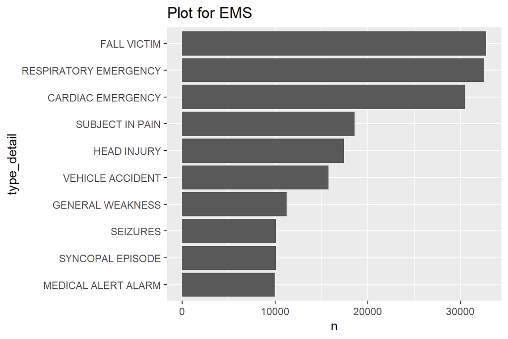

```r
names <- c("EMS", "Traffic", "Fire")
i <- 1
plots <- vector("list", 3)
for (name in names){
  plots[[i]] <- nine11_d %>%
    filter(type == name) %>%
    count(type_detail, sort = TRUE) %>%
    head(10) %>%
    mutate(type_detail = fct_reorder(as.factor(type_detail), n)) %>%
    ggplot(aes(x = n, y = type_detail)) +
    geom_bar(stat = "identity") +
    labs(title = paste0("Plot for ", name))
  i <- i + 1
}

plots[[1]]
```

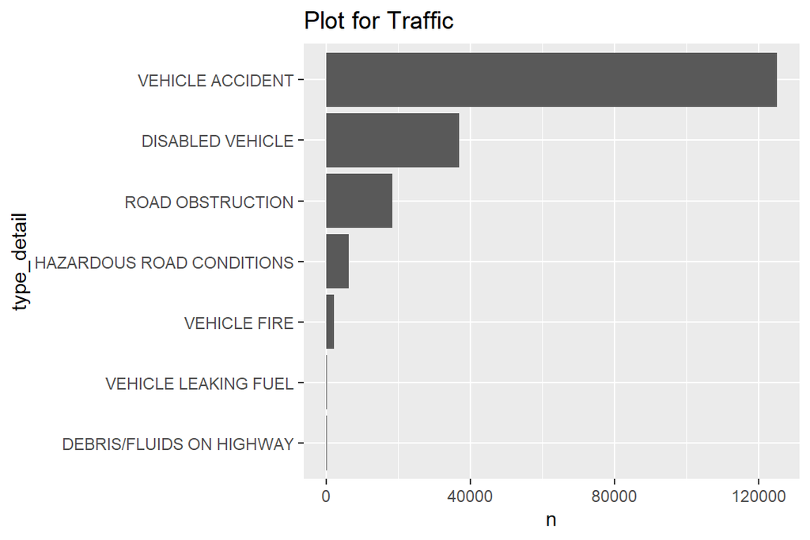

```r
plots[[2]]
```

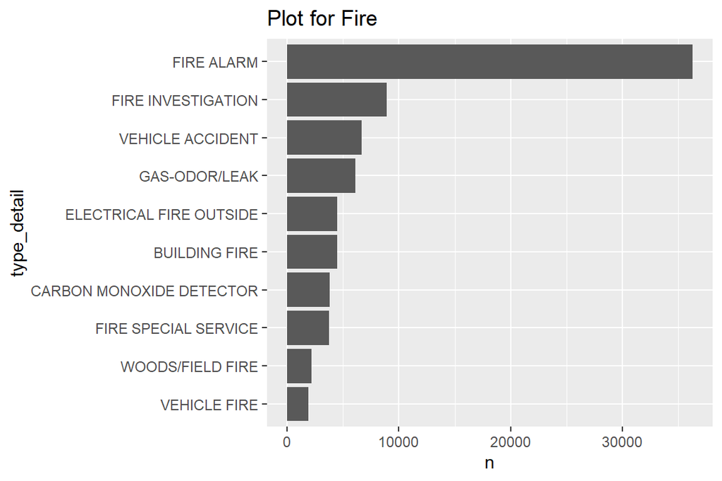

```r
plots[[3]]
```

#### **Question 6. Q4에서 얻은 dataset을 이용해 다음 물음에 답하시오. (총 15점)**

1. `timeStamp` 변수를 이용해 `year`, `month`, `day`, `wday`, `hour` 변수를 만드시오. (3점)  
   ex) `timeStamp` == “2015-12-10 17:10:52”인 경우 아래와 같이 생성. 요일은 한글 혹은 영어  
   `year` = 2015, `month` = 12, `day` = 10, `wday` = “목”, `hour` = 17

```r
nine11_fin <- nine11_d %>%
  mutate(
    year = year(timeStamp),
    month = month(timeStamp),
    day = day(timeStamp),
    wday = factor(
      str_remove(weekdays(timeStamp), "요일"),
      c("월", "화", "수", "목", "금", "토", "일")
    ),
    hour = hour(timeStamp)
  )
glimpse(nine11_fin)
```

```
## Rows: 583,199
## Columns: 15
## $ lat         <dbl> 40.29788, 40.25806, 40.12118, 40.11615, 40.25347, 40.18211…
## $ lng         <dbl> -75.58129, -75.26468, -75.35198, -75.34351, -75.28324, -75…
## $ desc        <chr> "REINDEER CT & DEAD END;  NEW HANOVER; Station 332; 2015-1…
## $ zip         <dbl> 19525, 19446, 19401, 19401, 19446, 19044, 19426, 19438, 19…
## $ type        <chr> "EMS", "EMS", "Fire", "EMS", "EMS", "EMS", "EMS", "EMS", "…
## $ type_detail <chr> "BACK PAINS/INJURY", "DIABETIC EMERGENCY", "GAS-ODOR/LEAK"…
## $ timeStamp   <dttm> 2015-12-10 17:10:52, 2015-12-10 17:29:21, 2015-12-10 14:3…
## $ twp         <chr> "NEW HANOVER", "HATFIELD TOWNSHIP", "NORRISTOWN", "NORRIST…
## $ addr        <chr> "REINDEER CT & DEAD END", "BRIAR PATH & WHITEMARSH LN", "H…
## $ station     <chr> "332", "345", "STA27", "308A", "345", "352", "336", "344",…
## $ year        <dbl> 2015, 2015, 2015, 2015, 2015, 2015, 2015, 2015, 2015, 2015…
## $ month       <dbl> 12, 12, 12, 12, 12, 12, 12, 12, 12, 12, 12, 12, 12, 12, 12…
## $ day         <int> 10, 10, 10, 10, 10, 10, 10, 10, 10, 10, 10, 10, 10, 10, 10…
## $ wday        <fct> 목, 목, 목, 목, 목, 목, 목, 목, 목, 목, 목, 목, 목, 목, 목…
## $ hour        <int> 17, 17, 14, 16, 15, 16, 16, 16, 17, 16, 17, 17, 17, 17, 17…
```

2. 요일/시간의 조합별 신고수를 하나의 heatmap으로 나타내시오.  
   신고횟수가 많은 요일, 시간대를 자유롭게 제시하시오. (3점)

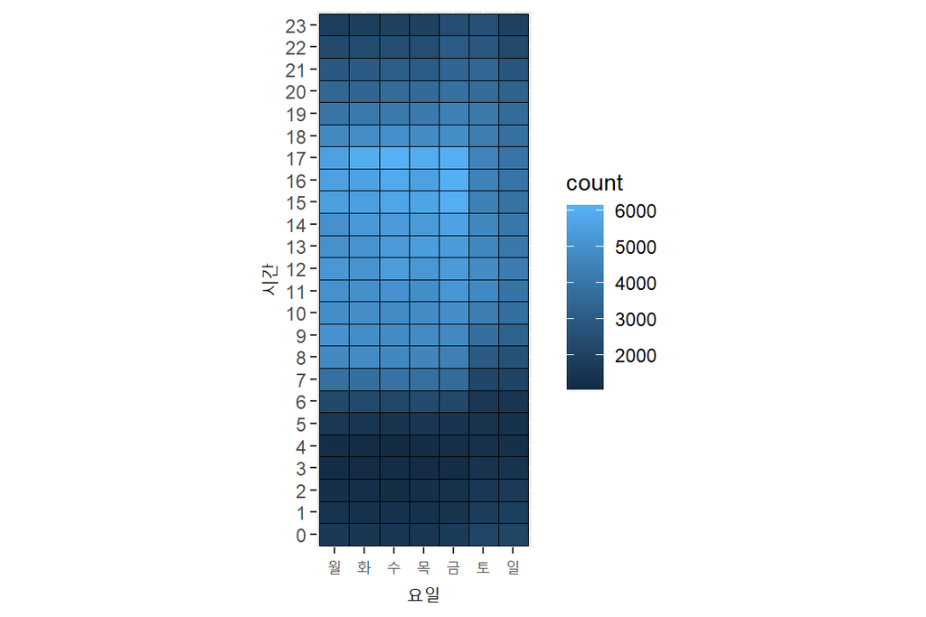

```r
ggplot(nine11_fin, aes(
  x = wday, y = factor(hour)
)) +
  geom_bin2d(binwith = c(1, 1), color = "black") +
  labs(x = "요일", y = "시간") +
  theme(aspect.ratio = 2.5)
```

금요일 17시! 확실하게 많다.  
전체적으로 주말보다 평일 특히 금요일이 많고,  
전체적으로 8시~17시가 신고가많다.

3. `VEHICLE ACCIDENT`은 `type_detail`의 종류 중 하나로, `type`==`EMS,Traffic`에서 등장한다.  
   요일/township의 조합별 `VEHICLE ACCIDENT` 발생 건수를 하나의 heatmap을 통해 나타내시오.  
   `VEHICLE ACCIDENT`이 많이 발생하는 지역, 요일을 자유롭게 제시하시오. (4점)

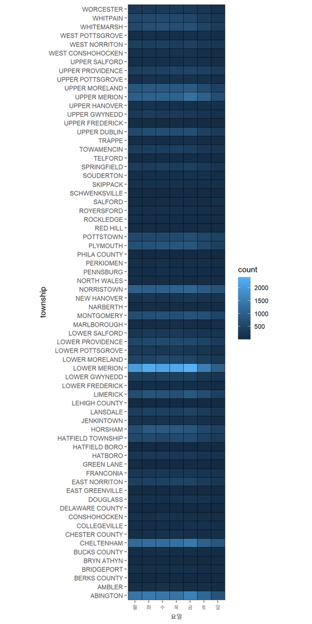

```r
nine11_fin %>%
  filter(type_detail == "VEHICLE ACCIDENT") %>%
  ggplot(aes(x = wday, y = twp)) +
  geom_bin2d(color = "black") +
  labs(x = "요일", y = "township") +
  theme(aspect.ratio = 6)
```

LOWER MERION에서 평일중 특히 금요일에 교통사고가 많이 일어난다.

4. 다음 기사는 2016년 Montgomery의 911 Service 손상과 관련된 기사이다. [Link](https://6abc.com/pennsylvania-news-montgomery-county-911/1575984/)  
   Cable cut으로 인해 `2016-10-27 14:00:00` ~ `2016-10-28 05:18:00` 동안 landline call에 문제가 생겼다.  
   위의 사건으로 인해, 해당 기간동안 신고 횟수의 변화가 있었는지 확인하고자 한다.  
   해당 기간 전후 3일간 신고량의 그래프를 `type`별로 그리고, cable cut의 영향이 있었는지 판단하시오.  
   한 plot 안에 type별 신고량이 색깔별로 나타나야 하며, cable cut 발생/복구 시간이 그래프에 나타나야 한다. (5점)

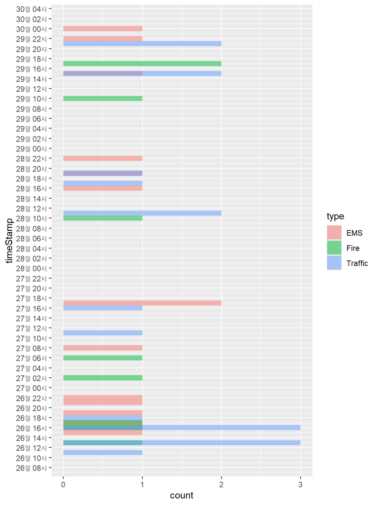

```r
nine11_fin %>%
  filter(year == 2016, month == 10, day %in% 26:29, twp == "MONTGOMERY") %>%
  ggplot(aes(x = timeStamp)) +
  geom_histogram(
    binwidth = 3600,
    aes(fill = type),
    position = "identity",
    alpha = 0.5
  ) +
  scale_x_datetime(date_labels = "%d일 %H시", date_breaks = "2 hours") +
  coord_flip()
```

10/27 14시부터 10/28 5시까지 3건의 신고만이 들어왔다.  
EMS 2건 Traffic 1건이다. Fire 신고는 아예 들어오지 않았다.  
15시간의 시간 범위를 잡았을 때 신고수가 3건인 것은 몽고메리 지역의 신고수가 적어서 충분히 일어날 수 있다. cable cut의 영향이 있었는지 알 수가 없다. cable cut 발생/복구 시간 또한 복구이후 신고가 한동안 들어오지 않았기에 확인할 수 없다.

## Topic 3 : Survey of Consumer Finances

2022년에 미국에서 실시한 소비자 금융 조사에 대해 분석하고자 한다. 주요 변수에 대한 설명은 다음과 같다.

| Variable | Attributes |
| --- | --- |
| `yy1` | Case ID |
| `age` | Age of reference person |
| `income` | Total amount of income of household |
| `checking` | Total value of checking accounts held by household |
| `saving` | Total value of savings accounts held by household |
| `stocks` | Total value of directly held stocks held by household |
| `bond` | Total value of directly held bonds held by household |
| `vehic` | Total value of all vehicles held by household |
| `houses` | Total value of primary residence of household |
| `nnresre` | Total value of net equity in nonresidential real estate held by household |
| `late` | Household had any late debt payments in last year |
| `late60` | Household had any debt payments more than 60 days past due in last year |
| `mrthel` | Total value of debt secured by the primary residence held by household |
| `install` | Total value of installment loans held by household |
| `edn_inst` | Total value of education loans held by household |
| `veh_inst` | Total value of vehicle loans held by household |
| `housecl` | Home-ownership category of household |
| `own` | have an owned vehicle |
| `noccbal` | Household does not carry a balance on credit cards |
| `credit_score` | Credit score of household (0~1000) |

#### **Question 7. 주어진 조건에 따라 자료를 정리하시오. [4점]**

- 금융자산의 총 가치를 계산하여 `fin` 변수에 저장하시오.
- 비금융자산의 총 가치를 계산하여 `nfin` 변수에 저장하시오.
- 자산 총 가치를 계산하여 `asset` 변수에 저장하시오.
- 순자산가치를 계산하여 `networth` 변수에 저장하시오.
- 연령대를 구분하여 `age.grp` 변수에 저장하시오.
- `networth`, `fin`, `nfin`이 `income`의 몇 배인지 각각 계산하고 `*_multiple` 변수에 저장하시오.

```r
new_scf <- scf %>%
  mutate(
    fin = checking + saving + stocks + bond,
    nfin = vehic + houses + nnresre,
    asset = fin + nfin,
    debt = install + edn_inst + veh_inst + mrthel,
    networth = asset - debt,
    networth_multiple = networth / income,
    fin_multiple = fin / income,
    nfin_multiple = nfin / income,
    age.grp = cut(
      age,
      c(0, 30, 35, 40, 45, 50, 55, 60, 67, 100),
      right = FALSE,
      labels = c(
        "zero", "one", "two", "three",
        "four", "six", "seven", "eigth", "ten"
      )
    )
  )
```

#### **Question 8. 사회 생활을 활발히 하는 30 ~ 67세 인구의 노후 대비에 대해 분석하고자 한다. 조건에 따라 분석하고 물음에 답하시오. [8점]**

- 아래의 그림은 연령별 노후 준비의 기준이다. 예를 들어, 50세에는 연봉 6배만큼의 자산이 있으면 노후 준비가 잘되어간다고 할 수 있다. 또한, 각 구간 안에서는 동일한 비율을 적용한다.

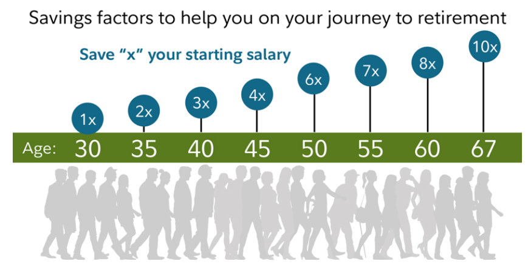

- 순자산, 금융자산, 비금융자산에 대하여 각각 제시된 기준보다 자산이 적은 사람과 많은 사람의 비율을 계산하여 예시와 같이 시각화하고 해석하여라.

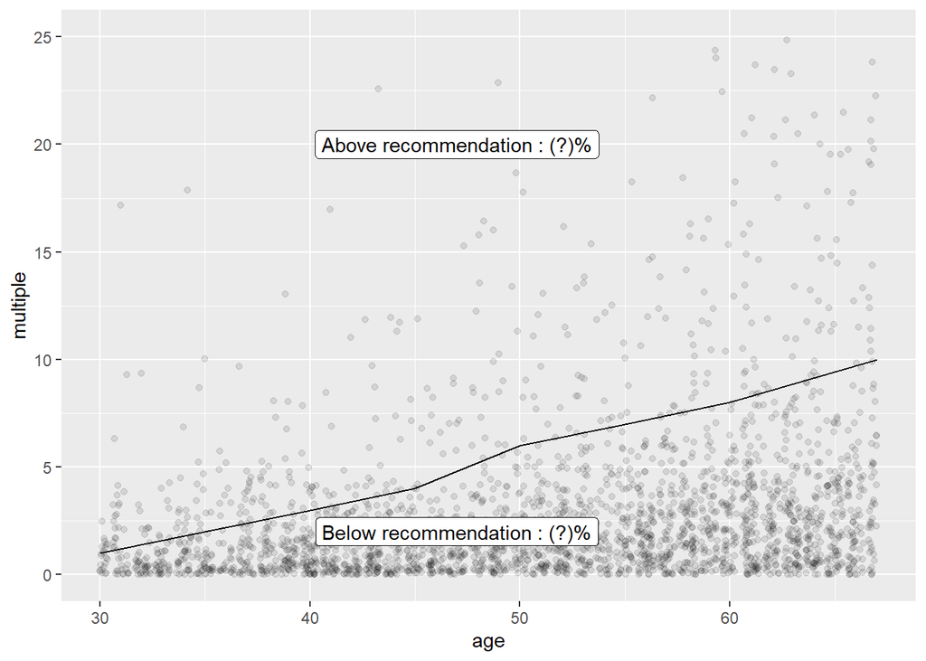

- 실선은 그림에서 제시한 연령별 노후 준비 기준을 시각화한 것이다.

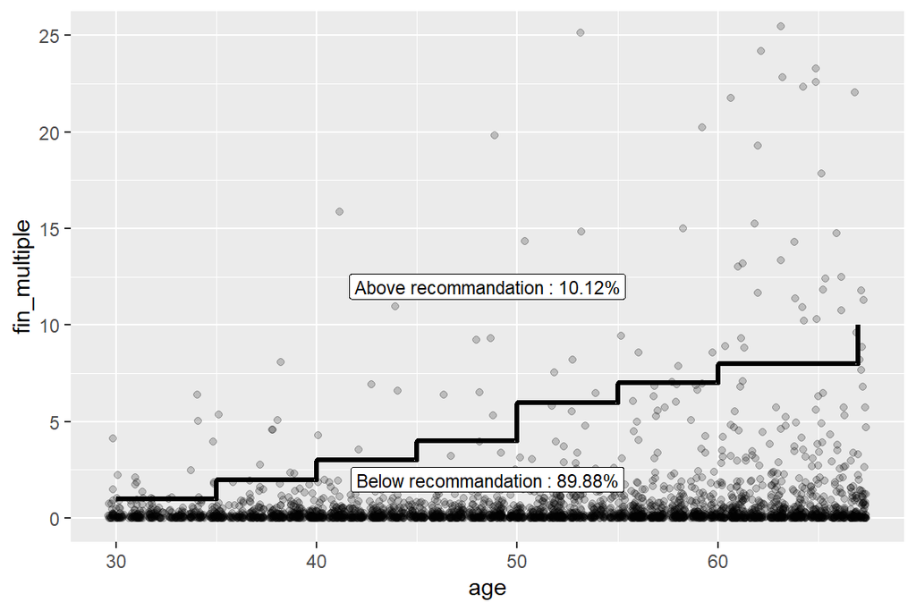

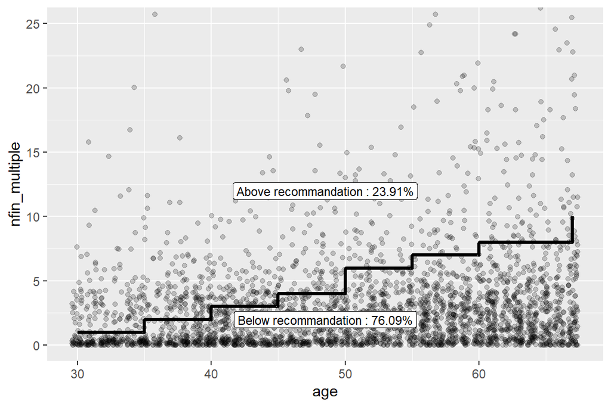

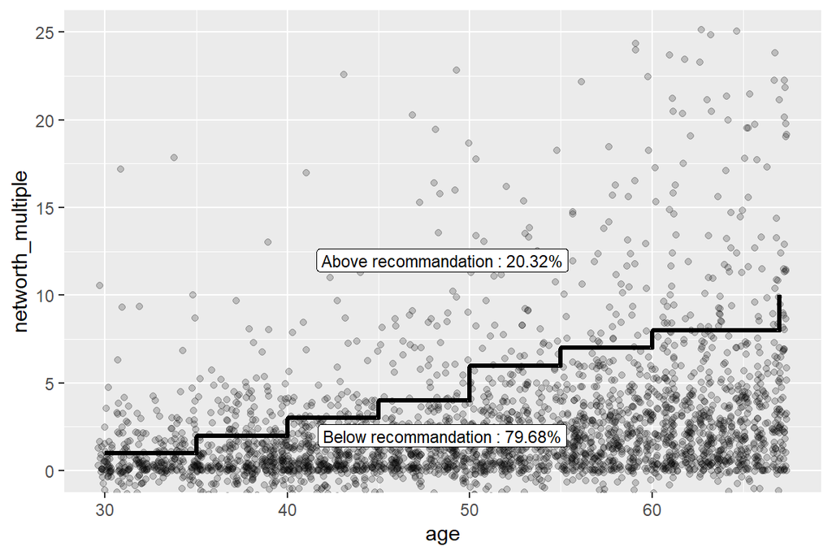

```r
ddata <- tibble(
  multi = c(0, 1, 2, 3, 4, 6, 7, 8, 10),
  ages = c(0, 30, 35, 40, 45, 50, 55, 60, 67),
  age.grp = new_scf$age.grp %>% levels()
)

nohoo <- new_scf %>%
  left_join(ddata, by = "age.grp") %>%
  mutate(
    fin_nohoo = fin_multiple > multi,
    nfin_nohoo = nfin_multiple > multi,
    networth_nohoo = networth_multiple > multi
  ) %>%
  summarise(
    ab_fin_rt = round(mean(fin_nohoo) * 100, 2),
    bl_fin_rt = 100 - round(mean(fin_nohoo) * 100, 2),
    ab_nfin_rt = round(mean(nfin_nohoo) * 100, 2),
    bl_nfin_rt = 100 - round(mean(nfin_nohoo) * 100, 2),
    ab_networth_rt = round(mean(networth_nohoo) * 100, 2),
    bl_networth_rt = 100 - round(mean(networth_nohoo) * 100, 2)
  ) %>%
  t() %>%
  as_tibble %>%
  mutate(
    x = 48.5,
    y = rep(c(12, 2), 3),
    label = paste0(
      rep(c("Above ", "Below "), 2),
      "recommandation : ",
      V1,
      "%"
    )
  )


map2(
  c("fin_multiple", "nfin_multiple", "networth_multiple"),
  c(1, 3, 5),
  ~new_scf %>%
    filter(age >= 30, age <= 67) %>%
    ggplot(aes(x = age)) +
    geom_jitter(aes(y = .data[[..1]]), alpha = 0.2, height = 0) +
    geom_step(data = ddata[-1, ], aes(ages, multi), linewidth = 1.2) +
    geom_label(data = nohoo[c(..2, ..2 + 1), ], aes(
      x = x,
      y = y,
      label = label
    ), size = 3) +
    coord_cartesian(ylim = c(0, 25))
)
```

30~67세에 대해 소득대비 자산이 매우 높은(2000배) 사람을 제외하고 대부분의 표본이 있는 0배~25배를 시각화하였다.  
금융자산과 비금융자산을 비교하였을 때, 보통 사람들은 금융자산보다 비금융자산을 통해서 노후 대비를 하고있음을 볼 수 있다.  
금융자산으로 생각했을때 노후 대비가 된 사람은 10.12%, 비금융자산의 경우 23.91%였다.  
순자산으로 보면 20.32%로 비금융보다 비율이 줄은 것을 알 수 있다.

#### **Question 9. 신용 점수를 예측하기 위한 모형을 다음 순서 및 조건에 따라 만들고 물음에 답하시오. [15점]**

- `sample()`을 이용하여 주어진 자료의 임의 표본 80%를 training set으로, 나머지 20%를 test set으로 설정하시오. [3점]
- training set에 대하여 다양한 선형 회귀 모형을 적합하시오. 단, 변수 선택 기준에 대해 서술하시오. [4점]
- test set에 대하여 예측한 `credit_score`와 관측된 `credit_score`의 SSE(Sum of squared error)가 가장 작은 모형을 선택하시오. [4점]
- 위 과정을 500번 반복한 후 가장 많이 선택된 모형을 신용 평가 모형으로 최종 선택하고 모형의 계수를 출력하시오. [4점]

```r
map_dbl(
  new_scf %>% select(-age.grp),
  ~cor(., new_scf$credit_score)
) %>%
  abs() %>%
  sort(decreasing = TRUE)
```

```
##      credit_score              late            mrthel            late60
##       1.000000000       0.452563362       0.308841191       0.305647133
##               age               own           noccbal              debt
##       0.205196055       0.200340516       0.181384028       0.178859885
##          edn_inst           install          checking            income
##       0.133967178       0.075193458       0.067512922       0.061785512
##          networth          veh_inst              bond             asset
##       0.056673778       0.054161847       0.053746373       0.052147193
##           nnresre              nfin               fin            saving
##       0.050601327       0.049198930       0.046300106       0.041152678
##            stocks      fin_multiple networth_multiple            houses
##       0.037002486       0.031905952       0.031835643       0.025419990
##           housecl     nfin_multiple               yy1             vehic
##       0.022687418       0.018166166       0.011146585       0.006487035
```

```r
fm1 <- credit_score ~ income + asset + debt + late
fm2 <- credit_score ~ age + income + debt + late + late60
fm3 <- credit_score ~ income + debt + asset + late + late60
fm4 <- credit_score ~ age + income + debt + asset + late + late60
fm5 <- credit_score ~ income + debt + asset + late + late60
fm6 <- credit_score ~ age + income + debt + late + late60 + own
fm7 <- credit_score ~ age + income + debt + late + late60 + noccbal + own
fm8 <- credit_score ~ age + income + debt +
  late + late60 + noccbal + own + asset

rs <- vector("double", 500)
for (i in 1:500) {
  train <- sample(seq_len(nrow(new_scf)), nrow(new_scf) * 0.8)
  train_set <- new_scf[train, ]
  test_set <- new_scf[-train, ]

  mod <- map(
    list(fm1, fm2, fm3, fm4, fm5, fm6, fm7, fm8),
    ~lm(., data = train_set)
  )

  rs[i] <- map_dbl(
    mod,
    ~mean((predict(., test_set) - test_set$credit_score)^2)
  ) %>%
    which.min()
}
table(rs)
```

```
## rs
##   7   8
## 400 100
```

```r
mod_fin <- lm(fm7, data = new_scf)
summary(mod_fin)
```

```
##
## Call:
## lm(formula = fm7, data = new_scf)
##
## Residuals:
##     Min      1Q  Median      3Q     Max
## -359.52  -47.28   -2.73   43.22  644.21
##
## Coefficients:
##               Estimate Std. Error t value Pr(>|t|)
## (Intercept)  7.111e+02  5.076e+00 140.096   <2e-16 ***
## age          1.037e+00  7.255e-02  14.297   <2e-16 ***
## income       1.045e-06  9.690e-08  10.782   <2e-16 ***
## debt        -1.639e-05  8.609e-07 -19.042   <2e-16 ***
## late        -1.418e+02  4.595e+00 -30.854   <2e-16 ***
## late60      -1.262e+01  6.915e+00  -1.825    0.068 .
## noccbal     -6.122e+01  2.421e+00 -25.286   <2e-16 ***
## own          4.901e+01  3.399e+00  14.418   <2e-16 ***
## ---
## Signif. codes:  0 '***' 0.001 '**' 0.01 '*' 0.05 '.' 0.1 ' ' 1
##
## Residual standard error: 75.59 on 4450 degrees of freedom
## Multiple R-squared:  0.3929, Adjusted R-squared:  0.3919
## F-statistic: 411.4 on 7 and 4450 DF,  p-value: < 2.2e-16
```

각 변수와 credit_score의 표본상관계수를 통하여 계수의 절댓값이 큰  
late, late60, age, own, noccbal, debt, income, asset으로 다양하게 모델을 만들어보았다.  
각 모델들은 age, late60, asset을 넣다 빼며 만들고, 점점 변수의 수를 늘려서도 만들었다.  
credit_score ~ age + income + debt + late + late60 + noccbal + own 모델이 500번중 많이 뽑히므로 최종모델로 선택하였다.

#### **Question 10. 어느 은행에서 은퇴자를 대상으로 비금융자산에 대해 담보 대출을 실시하고자 한다. 다음의 조건들을 참고하여 고객 정보를 입력하면 대출 가능 여부, 대출 한도, 금리를 산출하는 함수를 작성하여라. 채점 시 여러 조합의 입력값들에 대해 테스트하여 점수가 부여됨. [13점]**

- `age`… 을 설정 가능한 입력값으로 할 것. 또한, 신용 평가에 필요한 추가적인 변수들도 함수의 입력값으로 설정하시오. `asset`, `income`, `debt`, `late`
- 입력값의 형식이나 길이가 잘못 주어졌을 경우 에러 메세지를 출력하게 하시오.
- 나이가 67세 이하 or 채무 연체 기록 존재 or 부채가 $1000000 이상인 경우 대출이 불가하다. 이 경우 다음과 같은 메세지가 출력되도록 하시오. `Loans are not available.`
- 함수의 결과값은 다음과 같은 메세지가 출력되도록 하시오. `Loans are available. Credit line : (?)$, Interest rate : (?)%`
- 대출 한도는 비금융자산의 80%로 산정한다.
- 금리는 Q9에서 선택한 모형을 이용하여 Input으로 들어오는 고객의 정보를 통해 예측한 신용 점수를 바탕으로 산정하며 기준은 다음 표와 같다.

| Credit Score | Interest rate |
| --- | --- |
| 900 ~ 1000 | 1% |
| 800 ~ 899 | 2% |
| 700 ~ 799 | 3% |
| 600 ~ 699 | 4% |
| 500 ~ 599 | 5% |
| 400 ~ 499 | 6% |
| 300 ~ 399 | 7% |
| 200 ~ 299 | 8% |
| 100 ~ 199 | 9% |
| 0 ~ 99 | 10% |

```r
library(purrr)
loans <- function(
  age, income, debt, late, late60, noccbal, own, nfin, mod = mod_fin
) {
  ln <- length(c(age, income, debt, late, late60, noccbal, own, nfin))
  if (ln != 8) {
    stop("입력된 값들의 길이가 맞지않습니다. (단일 수치만 입력가능)")
  }
  isn <- map_dbl(
    c(age, income, debt, late, late60, noccbal, own, nfin), ~!is.numeric(.)
  )
  isl <- map_dbl(
    c(late, late60, noccbal, own), ~!(. %in% c(0, 1))
  )
  if (sum(isn + isl) != 0) {
    stop("올바른 형식이 아닙니다.")
  }
  if (!(age >= 67 && late == 0 && debt <= 1000000)) {
    return("Loans are not available.")
  }
  isp <- map_dbl(
    c(age, income, debt, late, late60, nfin), ~!(. >= 0)
  )
  if (sum(isp) != 0) {
    stop("양수만 입력하세요.")
  }
  my_data <- data.frame(
    age = age,
    income = income,
    debt = debt,
    late = late,
    late60 = late60,
    noccbal = noccbal,
    own = own
  )
  cs <- predict(mod, my_data)
  if (cs >= 1000) {
    interest <- 1
  } else if (cs <= 0) {
    interest <- 10
  } else {
    interest <- 10 - (cs %/% 100)
  }
  return(
    paste0(
      "Loans are available. Credit line : ", nfin * 0.8,
      "$, Interest rate : ", interest, "%"
    )
  )
}
loans(c(70, 28), 36448, 291800, 0, 0, 1, 1, 778000)
```

```
## Error in loans(c(70, 28), 36448, 291800, 0, 0, 1, 1, 778000): 입력된 값들의 길이가 맞지않습니다. (단일 수치만 입력가능)
```

```r
loans("adf", 464576, 0, 1, 0, 1, 0, 1398986)
```

```
## Error in loans("adf", 464576, 0, 1, 0, 1, 0, 1398986): 올바른 형식이 아닙니다.
```

```r
loans(70, 36448, 291800, 5, 0, 1, 1, 778000)
```

```
## Error in loans(70, 36448, 291800, 5, 0, 1, 1, 778000): 올바른 형식이 아닙니다.
```

```r
loans(70, 36448, -291800, 0, 0, 1, 1, 778000)
```

```
## Error in loans(70, 36448, -291800, 0, 0, 1, 1, 778000): 양수만 입력하세요.
```

```r
loans(68, 464576, 0, 1, 0, 1, 0, 1398986)
```

```
## [1] "Loans are not available."
```

```r
loans(46, 224830, 549800, 0, 0, 0, 1, 639800)
```

```
## [1] "Loans are not available."
```

```r
loans(79, 5277876, 1380000, 0, 0, 1, 1, 10005200)
```

```
## [1] "Loans are not available."
```

```r
loans(70, 36448, 291800, 0, 0, 1, 1, 778000)
```

```
## [1] "Loans are available. Credit line : 622400$, Interest rate : 3%"
```

## Topic 4 : Behavioral Risk Factor Surveillance System (BRFSS)

Behavioral Risk Factor Surveillance System(BRFSS)은 미국 CDC가 18세 이상 성인을 대상으로 전화 설문조사를 실시하여 건강 관련 정보를 수집하는 프로그램이다. 이 조사에는 나이, 인종, 성별, 소득, 교육 수준 등의 인구통계학적 변수와 만성질환 여부, 위험 행동, 의료 서비스 접근성 등 다양한 건강 관련 질문이 포함된다. 매년 약 40만 명의 응답자가 참여하며, 수집된 데이터는 모든 주에서 공통적으로 사용되는 핵심 문항(core component)과 일부 주에서만 선택적으로 포함되는 선택 모듈(optional modules)로 구성된다. 본 프로젝트에서는 2023년 데이터를 활용하였으며, 자세한 설명은 [공식 사이트](https://www.cdc.gov/brfss/annual_data/annual_2023.html)에서 확인할 수 있다.

`brfss2023.csv`는 이 프로젝트를 위해 추려진 변수들을 포함하고 있는 데이터셋이며, 첨부된 코드북(`brfss2023_codebook.html`)에 각 변수명에 대한 설명이 기재되어 있다. 따라서 프로젝트 수행 시 해당 파일에서 변수명으로 검색하여 필요한 정보를 얻을 수 있다. (`X_*` 변수들은 `X`를 제외한 `_*`로 검색해야 한다.) 또한, `states.csv`는 주별 FIPS 코드를, `modules2023.csv`는 선택 모듈별로 참여 주에 대한 데이터셋이다.

#### **Question 11. (States and Optional Modules)**

1. BRFSS 데이터를 불러온 후 조건에 맞게 변형하고, 결과를 출력하여라. [2점]
- `brfss2023.csv` 데이터를 불러와 변수 `brfss`에 저장한다.
- `states.csv`를 이용하여 state FIPS code를 나타내는 `X_STATE` 대신 이름을 나타내는 `state` 변수를 첫 번째 열로 추가한다.
- 다섯 개의 행을 랜덤하게 출력하라.

```r
brfss <- read_csv(paste0(wd, "brfss2023.csv"))
modules <- read_csv(paste0(wd, "modules.csv"))
states <- read_csv(paste0(wd, "states.csv"))
new_brfss <- brfss %>%
  left_join(states, by = c("X_STATE" = "value")) %>%
  dplyr::select(state, everything(), -X_STATE)

slice_sample(new_brfss, n = 5)
```

```
## # A tibble: 5 × 23
##   state      X_AGE_G X_SEX X_RACEPRV X_INCOMG1 X_EDUCAG SOMALE SOFEMALE TRNSGNDR
##   <chr>        <dbl> <dbl>     <dbl>     <dbl>    <dbl>  <dbl>    <dbl>    <dbl>
## 1 Missouri         5     1         1         5        4      2       NA        4
## 2 Connectic…       5     2         1         7        4     NA        2        4
## 3 Minnesota        5     2         1         9        3     NA        2        4
## 4 Washington       6     1         1         5        3      2       NA        4
## 5 Vermont          6     2         1         9        4     NA        2        4
## # ℹ 14 more variables: X_MICHD <dbl>, ADDEPEV3 <dbl>, X_RFSMOK3 <dbl>,
## #   ACEHURT1 <dbl>, ACETOUCH <dbl>, ACETTHEM <dbl>, ACEHVSEX <dbl>,
## #   ACESWEAR <dbl>, ACEDEPRS <dbl>, ACEDRINK <dbl>, ACEDRUGS <dbl>,
## #   ACEPRISN <dbl>, ACEDIVRC <dbl>, ACEPUNCH <dbl>
```

2. 선택 모듈은 일부 주에서만 채택하여 사용하므로, 관심 있는 연구 질문에 답하기 위해 특정 모듈을 사용한 주가 어디인지 알아내고 싶다고 하자. `modules.csv`를 이용해 다음 조건을 만족하는 함수를 작성하고 해당하는 결과를 출력하여라. [5점]
- 입력값으로 길이 1 이상의 모듈명 벡터를 받는다.
- 주어진 모듈들을 모두 채택하여 설문에 사용한 주들의 이름 벡터를 반환(`return`)한다.
- 이때, 존재하지 않는 모듈(들)이 입력으로 주어지면, 그 모듈명을 모두 포함한 다음과 같은 메시지와 함께 error가 발생하도록 한다. `"The following module(s) do not exist: <all non-existent module names>".`
- (예시 1), (예시 2) 각각에 해당하는 입력값으로 함수를 실행하여라. 이때, (예시 2)는 에러를 발생시키므로 R Markdown에서 해당 code chunk만 `error=TRUE`로 설정하여 에러가 발생하여도 성공적으로 knit가 될 수 있도록 한다.

**예시 1**. (valid)

```r
states_ace = get_states_by_modules(c("Adverse Childhood Experiences", "Sexual Orientation and Gender Identity (SOGI)")) states_ace
```

```
## [1] "Delaware"     "Georgia"      "Missouri"     "Nevada"       "New Jersey"
 ## [6] "Rhode Island" "Virginia"
```

**예시 2**. (error)

```r
get_states_by_modules(c("Adverse Childhood Experiences", "Depression", "This module doesn't exist!"))
```

```
## Error in get_states_by_modules(c("Adverse Childhood Experiences", "Depression")), : The following module(s) do not exist: Depression, This module doesn't exist!
```

```r
library(stringr)
library(dplyr)
get_states_by_modules <- function(v, data = modules) {
  if (!((diff <- setdiff(v, data$module)) |> length()) == 0) {
    stop(
      paste0(
        "The following module(s) do not exist: ",
        paste0("'", diff, "'", collapse = ", "),
        "."
      )
    )
  }
  my_data <- data.frame(module = v) %>% left_join(data)
  return(Reduce(intersect, str_split(my_data$states, ", ")))
}

states_ace <- get_states_by_modules(
  c(
    "Adverse Childhood Experiences",
    "Sexual Orientation and Gender Identity (SOGI)"
  )
)
states_ace
```

```
## [1] "Delaware"     "Georgia"      "Missouri"     "Nevada"       "New Jersey"
## [6] "Rhode Island" "Virginia"
```

```r
get_states_by_modules(c(
  "Adverse Childhood Experiences",
  "Depression",
  "This module doesn't exist!"
))
```

```
## Error in get_states_by_modules(c("Adverse Childhood Experiences", "Depression", : The following module(s) do not exist: 'Depression', 'This module doesn't exist!'.
```

#### **Question 12. (Data Preprocessing)**

Adverse Childhood Experience(ACE)는 개인의 건강에 장기적으로 부정적 영향을 끼칠 수 있는 것으로 알려져 있다. 이러한 현상을 2023년 BRFSS 데이터를 통해 확인해보고자 한다. 특히 관심있는 건강 관련 반응변수는 심혈관 질환 발병 여부이다.

참고. [About Adverse Childhood Experiences](https://www.cdc.gov/aces/about/index.html)

선택 모듈 ’Adverse Childhood Experiences’를 사용한 Nevada 주로 한정하여 분석을 진행하고자 한다. 다음과 같이 Nevada 주의 데이터만 필터링한 `df` 변수를 생성하자.

```r
df <- brfss |>
  filter(state == "Nevada") |>
  select(-c(state, X_STATE))
```

1. ACE를 아래 표와 같이 8개의 세부 카테고리로 분류하자. 다음 조건에 맞게 ACE 문항들을 8개의 세부 카테고리로 정리하고, 그 결과를 시각화하여라. [6점]
- Scoring 기준을 따라 phys_abuse, sex_abuse 등의 8개의 이진형 변수를 만든다.
- “Don’t know/Not Sure”, “Refused”와 missing 모두 0으로 처리한다.
- 세부 카테고리 별로 발생 빈도를 나타내는 막대 그래프를 그린다. 이때, 막대들을 발생 빈도 순으로 정렬하고, 각 막대 위에 발생 빈도를 백분율(%) 단위로 label한다. 빈도를 계산할 때 NA 값은 무시한다. (Hint: `mean(. na.rm=TRUE)`)

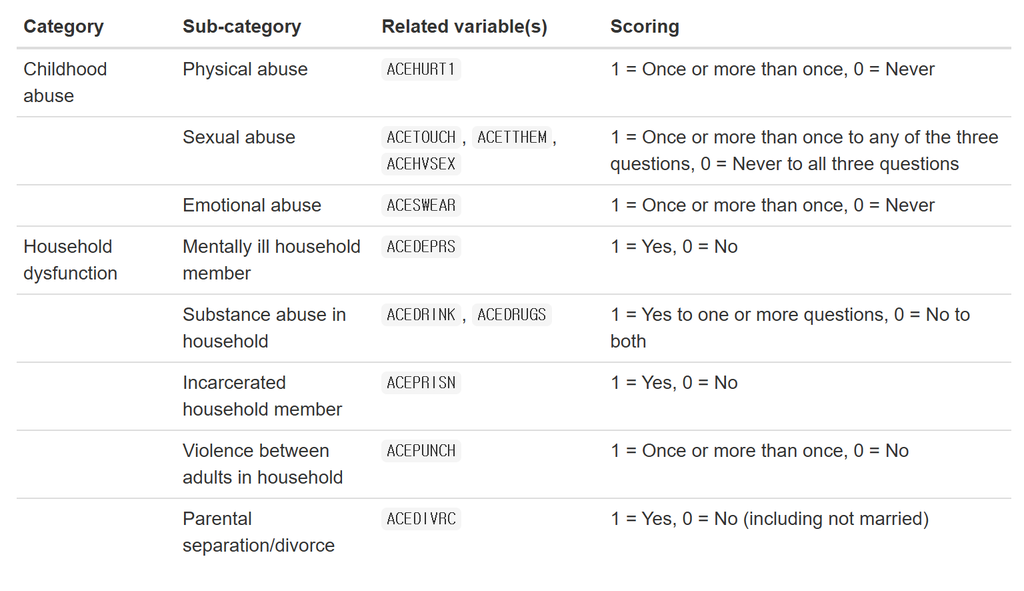

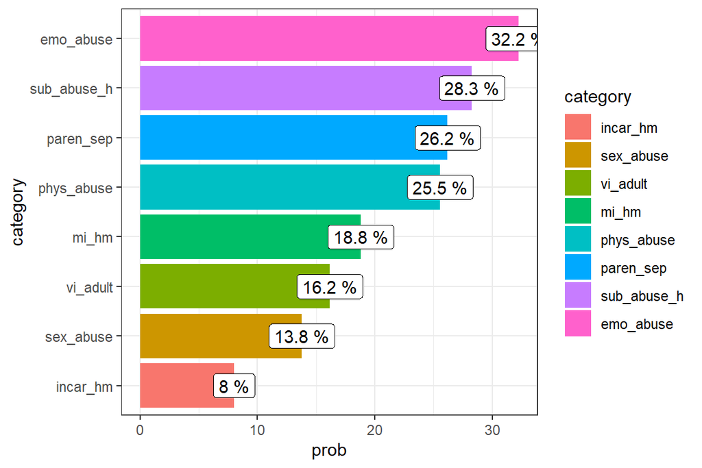

```r
get_binary_freq <- function(v) {
  if (v %in% c(1, 7, 8, 9, NA)) {
    return(0)
  } else {
    return(1)
  }
}
get_binary_yn <- function(v) {
  if (v %in% c(2, 7, 8, 9, NA)) {
    return(0)
  } else {
    return(1)
  }
}

df <- new_brfss %>%
  filter(state == "Nevada") %>%
  select(-state) %>%
  mutate(
    phys_abuse = map_dbl(ACEHURT1, get_binary_freq),
    ACETOUCH = map_dbl(ACETOUCH, get_binary_freq),
    ACETTHEM = map_dbl(ACETTHEM, get_binary_freq),
    ACEHVSEX = map_dbl(ACEHVSEX, get_binary_freq),
    sex_abuse = ifelse(ACETOUCH + ACETTHEM + ACEHVSEX > 0, 1, 0),
    emo_abuse = map_dbl(ACESWEAR, get_binary_freq),
    mi_hm = map_dbl(ACEDEPRS, get_binary_yn),
    ACEDRINK = map_dbl(ACEDRINK, get_binary_yn),
    ACEDRUGS = map_dbl(ACEDRUGS, get_binary_yn),
    sub_abuse_h = ifelse(ACEDRINK + ACEDRUGS > 0, 1, 0),
    incar_hm = map_dbl(ACEPRISN, get_binary_yn),
    vi_adult = map_dbl(ACEPUNCH, get_binary_freq),
    paren_sep = map_dbl(ACEDIVRC, get_binary_yn)
  )


df %>%
  summarise_at(vars(-(1:22)), ~mean(.) * 100) %>%
  pivot_longer(everything(), names_to = "category", values_to = "prob") %>%
  mutate_at("category", ~fct_reorder(as_factor(.), prob)) %>%
  ggplot(aes(x = category, y = prob)) +
  geom_bar(aes(fill = category), stat = "identity") +
  geom_label(aes(label = paste(round(prob, 1), "%"))) +
  coord_flip() +
  theme_bw()
```

2. ACE score를 모든 세부 카테고리 점수의 합으로 정의하자. ACE score는 0에서 8까지의 값을 가질 수 있다. 또한, ACE score가 3 이상이면 “high”, 0~2이면 “low”로 정의하자. [3점]
- ACE score를 나타내는 `ace_score` 열을 추가한다.
- ACE score를 이산화하여 3 이상이면 “high”, 0~2이면 “low”의 값을 가지는 factor `ace_hl` 열을 생성한다. 이때, factor level의 순서는 “low”, “high”로 지정한다.
- 각 ACE 레벨(`ace_hl`)별 count를 출력한다.

```r
df_b <- df %>%
  mutate(ace_score = rowSums(df[, -(1:22)])) %>%
  mutate(ace_hl = cut(
    ace_score,
    breaks = c(-Inf, 2, Inf),
    labels = c("low", "high")
  ))

df_b %>% count(ace_hl)
```

```
## # A tibble: 2 × 2
##   ace_hl     n
##   <fct>  <int>
## 1 low     1906
## 2 high     744
```

3. 심혈관 질환(Cardiovascular disease, 이하 CVD) 발병 여부에 대한 변수 `X_MICHD`를 다음 조건에 따라 적절히 변환하고, 결과를 확인하여라. [2점]
- 1 = Yes, 0 = No인 이진형 numeric 벡터 `cvd` 열을 생성한다.
- missing은 그대로 `NA`로 처리한다.
- `1`, `0`, `NA` 각각의 개수와 발병률(non-NA 응답 중 1의 비율)을 출력한다.

```r
df_c <- df_b %>%
  mutate(cvd = (2 - X_MICHD))
df_c %>% count(cvd)
```

```
## # A tibble: 3 × 2
##     cvd     n
##   <dbl> <int>
## 1     0  2413
## 2     1   210
## 3    NA    27
```

```r
mean(df_c$cvd, na.rm = TRUE)
```

```
## [1] 0.080061
```

1은 210, 0은 2413, NA는 27개이다.  
발병률은 0.08이다.

4. 한편, CVD는 특정 조건의 사람들에게서 더 흔하게 발병할 수 있다. 관련된 몇 가지 주요 인구통계학적 변수는 성별, 나이, 인종, 교육 수준이다. 해당 변수들을 다음 조건에 맞게 factor로 변환하여라. [4점]

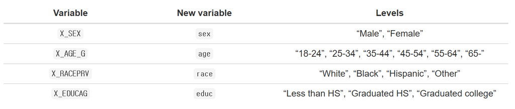

- 기존 변수(Variable)에서 조건에 맞는 새로운 factor 변수(New variable)를 생성하는데, 몇몇 변수는 기존 변수와 다른 factor level을 갖고 있다는 점을 유의한다. (예. White, Black, Hispanic 이외의 인종은 모든 Other로 합친다.)
- Factor level은 표의 Levels에 기재된 순서를 보존해야 한다.
- “Don’t know/Not Sure”, “Refused”와 missing 모두 `NA`로 처리한다.

**분석에 활용할 모든 변수를 적절하게 변환했으므로, 변환된 변수(`cvd`, `ace_hl`, `sex`, `age`, `race`, `educ`) 외의 변수는 제거한다.**

```r
df = df |> select(cvd, ace_hl, sex, age, race, educ)
```

```r
df_fin <- df_c %>%
  mutate(
    sex = factor(X_SEX, labels = c("MALE", "FEMALE")),
    age = factor(
      X_AGE_G,
      labels = c("18-24", "25-34", "35-44", "45-54", "55-64", "65-")
    ),
    race = factor(
      X_RACEPRV,
      labels = c("White", "Black", rep("Other", 5), "Hispanic")
    ) %>%
      fct_relevel(c("White", "Black", "Hispanic", "Other")),
    educ = factor(
      ifelse(X_EDUCAG == 9, NA, X_EDUCAG),
      labels = c(
        "Less than HS",
        rep("Graduated HS", 2),
        "Graduated college"
      )
    )
  ) %>%
  select(cvd, ace_hl, sex, age, race, educ)
glimpse(df_fin)
```

```
## Rows: 2,650
## Columns: 6
## $ cvd    <dbl> 1, 0, 0, NA, 0, 0, 0, 0, 1, 0, 0, 0, 0, 1, 1, 0, 0, 0, 0, 1, 0,…
## $ ace_hl <fct> low, low, low, low, low, high, low, low, high, low, low, high, …
## $ sex    <fct> MALE, MALE, FEMALE, MALE, MALE, FEMALE, FEMALE, MALE, MALE, FEM…
## $ age    <fct> 65-, 55-64, 65-, 65-, 65-, 65-, 45-54, 55-64, 55-64, 65-, 65-, …
## $ race   <fct> White, White, White, White, White, White, White, White, White, …
## $ educ   <fct> Graduated HS, Graduated college, Graduated college, Graduated H…
```

#### **Question 13. (Modelling)**

1. ACE와 CVD 연관성을 단순하게 파악해보자. Low ACE score 그룹에 비해 high ACE score 그룹에서 CVD의 발병 빈도가 증가하는가? 이 결과에 대해 어떻게 생각하는가? [2점]

```r
df_fin %>%
  summarise(rt = mean(cvd, na.rm = TRUE), .by = ace_hl)
```

```
## # A tibble: 2 × 2
##   ace_hl     rt
##   <fct>   <dbl>
## 1 low    0.0807
## 2 high   0.0785
```

오히려 high그룹이 발병빈도가 더 낮다. 예측과 달라 조금 당황스럽긴하다. 하지만 인구통계학적 변수를 추가하였을 때 ace의 설명력이 높아져 다른 결과가 나올 것 같다.

2. 인구통계학적 변수들이 관심 반응변수인 CVD 발병 여부와 어떤 관련이 있는지 알아보자. [6점]
- 각 인구통계학적 변수에 대해, factor 레벨에 따라 CVD 발병률이 어떻게 변화하는지 그래프 또는 표를 통해 탐색하고 결과를 논하여라.
- 두 개의 인구학적 변수들의 조합(변수1, 변수2)에 대해 CVD 발병률을 확인하고자 한다. x축을 변수1, y축을 CVD 발병률로 하는 막대 그래프를 변수2 레벨에 따라 색으로 구분하여 그려라. 각 그래프가 드러내는 경향성을 논하여라. (Hint: 총 6개의 그래프를 그려야 한다.)

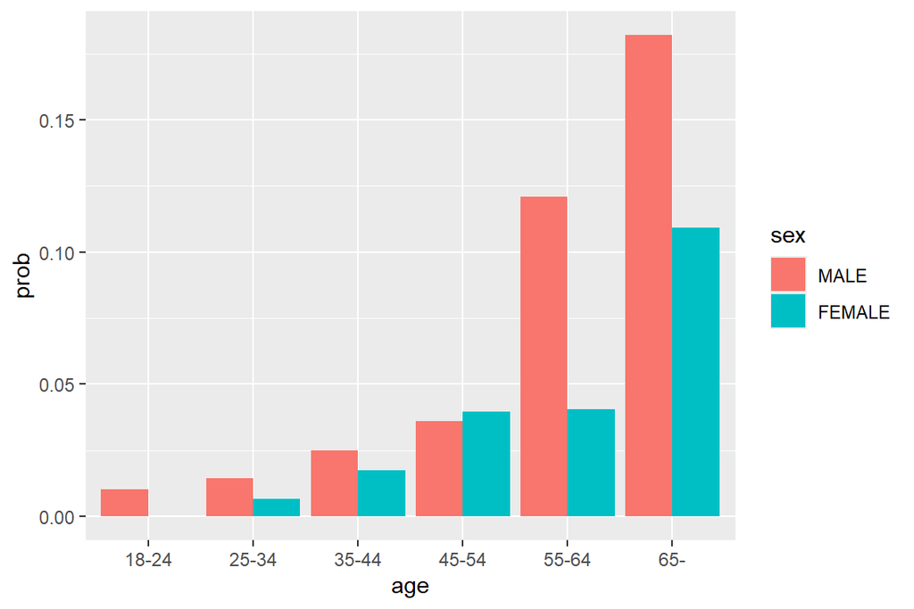

```r
df_fin %>%
  summarise(prob = mean(cvd, na.rm = TRUE), .by = c(sex, age)) %>%
  ggplot(aes(y = prob, x = age, fill = sex)) +
  geom_bar(stat = "identity", position = "dodge")
```

나이가 많을수록 발병률이 높아지는 추세를 보이고 있고,  
남성의 나이에따른 발병률이 여성보다 빠르게 증가한다.

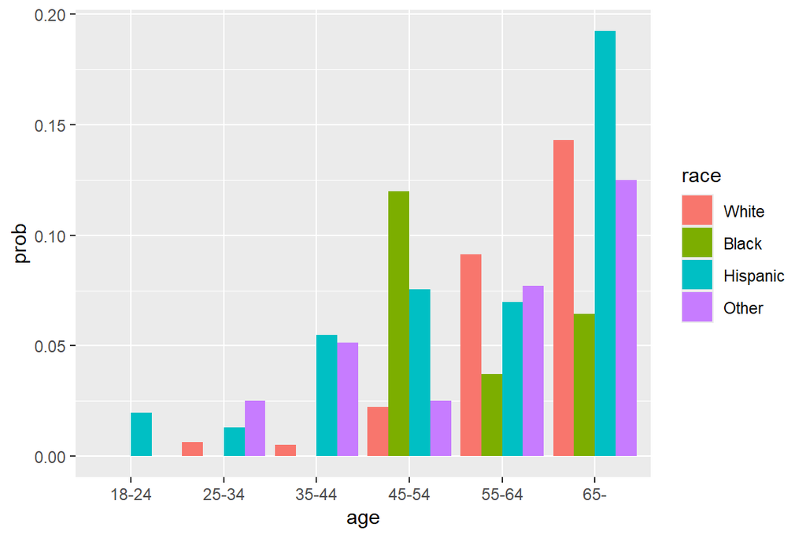

```r
df_fin %>%
  summarise(prob = mean(cvd, na.rm = TRUE), .by = c(race, age)) %>%
  ggplot(aes(y = prob, x = age, fill = race)) +
  geom_bar(stat = "identity", position = "dodge")
```

역시 나이에 따라 발병률이 오른다.  
백인은 나이에 따라 발병률이 오르는게 잘 보이는데,  
나머지 변수는 확실하지는 않지만 비슷한 경향성을 보인다.  
각 인종끼리의 비교는 나이대마다 다 다르다.

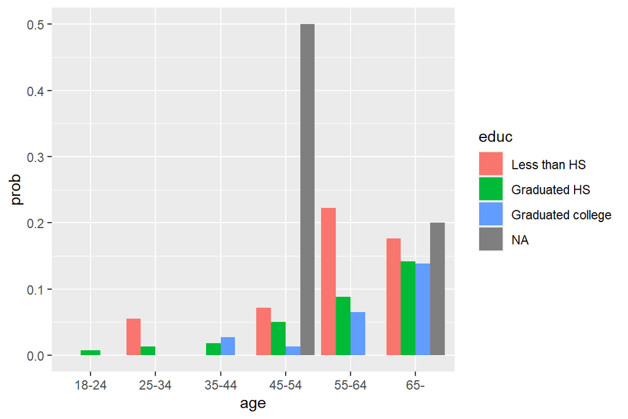

```r
df_fin %>%
  summarise(prob = mean(cvd, na.rm = TRUE), .by = c(educ, age)) %>%
  ggplot(aes(y = prob, x = age, fill = educ)) +
  geom_bar(stat = "identity", position = "dodge")
```

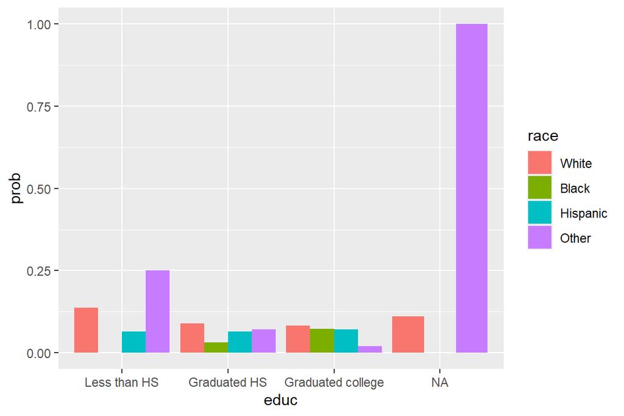

```r
df_fin %>%
  summarise(prob = mean(cvd, na.rm = TRUE), .by = c(educ, race)) %>%
  ggplot(aes(y = prob, x = educ, fill = race)) +
  geom_bar(stat = "identity", position = "dodge")
```

NA는 제외하고 보자  
위의 결과와같이 Less than HS가 비율이 높다.  
각 인종에 대해서는 위에서와 같이 각 그룹마다 우세가 다 다르다.

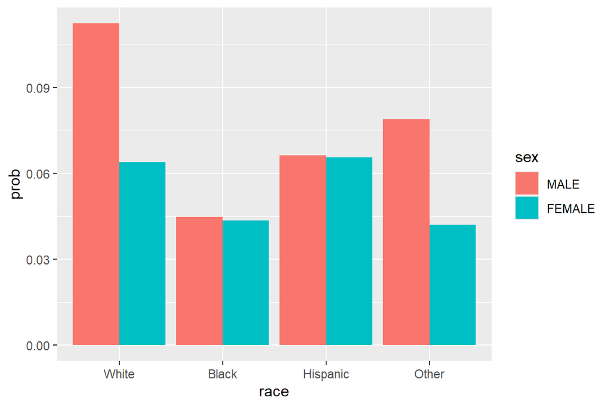

```r
df_fin %>%
  summarise(prob = mean(cvd, na.rm = TRUE), .by = c(sex, race)) %>%
  ggplot(aes(y = prob, x = race, fill = sex)) +
  geom_bar(stat = "identity", position = "dodge")
```

모든 인종에대해 남성이 여성보다 더 높은 발병률을 보인다.  
인종중에는 white가 대체적으로 발병률이 높은 편이다.

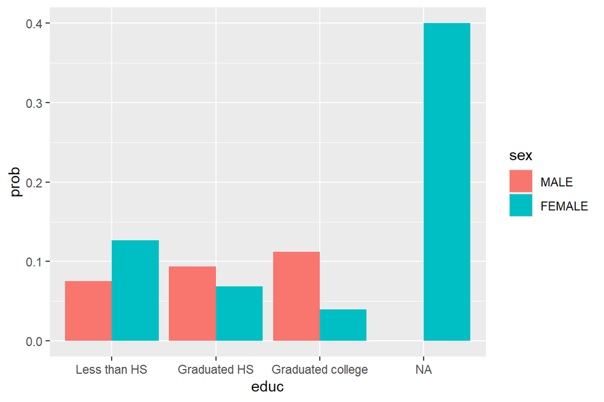

```r
df_fin %>%
  summarise(prob = mean(cvd, na.rm = TRUE), .by = c(sex, educ)) %>%
  ggplot(aes(y = prob, x = educ, fill = sex)) +
  geom_bar(stat = "identity", position = "dodge")
```

남성은 학력이 높을수록 발병률이 높고  
여성은 그 반대이다.  
통합하여 보면 Less than HS가 발병률이 높은 것을 알 수 있다.  
성별과 학력사이에 발병률에 미치는 어떠한 관계가 있음을 알 수 있다.

3. ACE가 CVD 발병에 미치는 영향을 통계적으로 모델링하고자 한다. 이때 반응변수는 이진형이므로 로지스틱 회귀 모델을 적합하는 것이 적절하다. 앞선 결과를 토대로 적절한 로지스틱 회귀 모델을 적합하고 결과를 분석하여라. [4점]
- 앞의 결과를 토대로 모델 적합 시 인구통계학적 변수 역시 포함해야 하는 이유를 서술하여라.
- `glm()`을 이용하여 로지스틱 회귀 모델을 적합하고 결과를 간단하게 서술하여라.

```r
mod <- glm(cvd ~ ., data = df_fin, family = binomial)
summary(mod)
```

```
##
## Call:
## glm(formula = cvd ~ ., family = binomial, data = df_fin)
##
## Coefficients:
##                       Estimate Std. Error z value Pr(>|z|)
## (Intercept)            -4.7722     1.0769  -4.431 9.37e-06 ***
## ace_hlhigh              0.2807     0.1689   1.662 0.096465 .
## sexFEMALE              -0.6993     0.1533  -4.560 5.12e-06 ***
## age25-34                0.6911     1.1602   0.596 0.551377
## age35-44                1.4461     1.0755   1.345 0.178732
## age45-54                2.0106     1.0478   1.919 0.054991 .
## age55-64                2.9519     1.0215   2.890 0.003854 **
## age65-                  3.6491     1.0136   3.600 0.000318 ***
## raceBlack              -0.3558     0.4374  -0.814 0.415911
## raceHispanic            0.4224     0.2649   1.594 0.110878
## raceOther              -0.0843     0.3083  -0.273 0.784531
## educGraduated HS       -0.3521     0.3548  -0.992 0.321114
## educGraduated college  -0.5240     0.3652  -1.435 0.151347
## ---
## Signif. codes:  0 '***' 0.001 '**' 0.01 '*' 0.05 '.' 0.1 ' ' 1
##
## (Dispersion parameter for binomial family taken to be 1)
##
##     Null deviance: 1451.6  on 2611  degrees of freedom
## Residual deviance: 1293.6  on 2599  degrees of freedom
##   (38 observations deleted due to missingness)
## AIC: 1319.6
##
## Number of Fisher Scoring iterations: 7
```

4.13.b의 결과를 보았을때 각 인구통계학적 변수가 cvd에 미치는 영향이 꽤나 분명하고, 이를 모델링에 넣으면 ace_hl이 cvd에 미치는 영향이 더 정확하게 구별되어 나타날 수 있다.  
그래서 인구통계학적 변수를 넣어서 모델링을 해야한다.

위의 로지스틱 회귀분석의 결과를 보면, 유의확률이 0.05보다 낮아서 유의한 변수는 다음과 같다.  
sexFEMALE, age55-64, age65-  
성별과 나이가 cvd에 미치는 영향이 유의하다는 것을 알 수 있다. 성별은 여성이면 발병률이 낮은 경향성이고, 나이는 많을수록 발병률이 높은 경향성이다. ace_hl은 유의확률 0.097로 유의하지 않다, 하지만 단순히 그룹화해서 비교할때와는 다르게 회귀계수가 0.2807로 양수라서 ace_hl이 high이면 발병률의 로그 오즈를 더 높이는 것으로 된다.  
인구통계학적 변수를 넣음으로 ace_hl이 미치는 영향이 더 잘 드러났다고 볼 수 있다.

4. 적합된 로지스틱 회귀 모델이 주어진 변수 값에 따라 CVD 발병 확률을 어떻게 예측하는지 시각화를 통해 알아보자. [6점]
- x축을 `age`로, y축을 CVD 발병 확률 예측값으로 선 그래프를 그리는데, `ace_hl`은 색으로, `sex`는 선의 종류(`linetype`)로 구분하고, `facet_grid()`를 이용해 (`educ`, `race`) 조합별로 12개의 플롯을 생성한다. 이해를 돕기 위해 적절한 label과 legend를 추가한다. (Hint: 주어진 변수 값에서 CVD 발병 확률의 예측값은 `predict(., type="response")`로 구할 수 있다.)
- 그림을 바탕으로 적합된 로지스틱 회귀 모형이 예측하는 ACE와 CVD 발병의 관계를 설명하여라.

```
## `geom_line()`: Each group consists of only one observation.
## ℹ Do you need to adjust the group aesthetic?
```

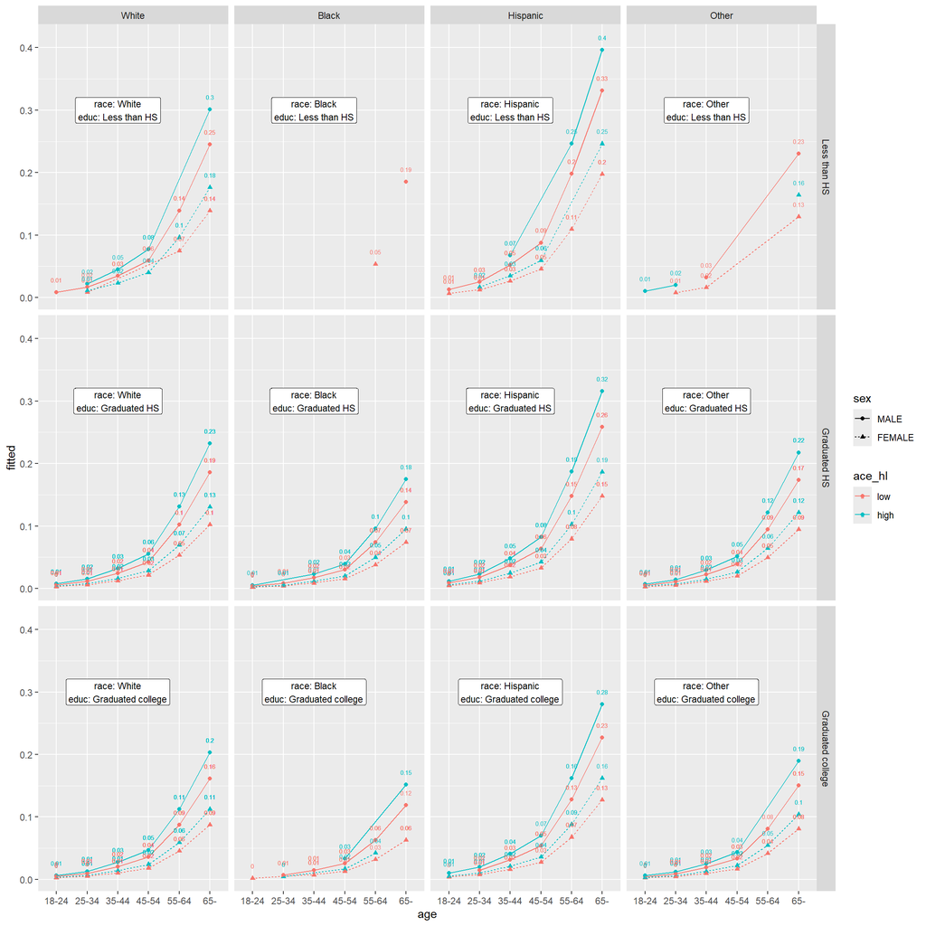

```r
df_fin %>%
  na.omit() %>%
  mutate(fitted = predict(mod, type = "response")) %>%
  ggplot(
    aes(x = age, y = fitted, group = interaction(ace_hl, sex))
  ) +
  geom_point(aes(shape = sex, color = ace_hl)) +
  geom_line(aes(linetype = sex, color = ace_hl)) +
  geom_text(
    aes(label = round(fitted, 2), color = ace_hl),
    size = 2,
    nudge_y = 0.02
  ) +
  geom_label(aes(x = "35-44", y = 0.3, label = paste0(
    "race: ", race,
    "\neduc: ", educ
  )), size = 3) +
  facet_grid(educ ~ race)
```

거의 대부분의 plot에서 파란 점선이 빨간 점선보다 위, 파란 실선이 빨간 실선보다 위임을 알 수 있다.  
그래프로 보았을때 ace_hl이 high인 데이터들이 low인 데이터보다 발병률의 예측값이 높음을 알 수 있다.  
회귀모델을 통하여 보았을 때 ace_hl이 high이면 발병률이 높다고 예측한다.  
모든 그룹에서 나이가 많아질수록 발병률의 예측값은 높아진다.  
또한 성별로 보았을때 실선이 점선보다 항상 위에 있어서, 남자이면 발병률의 예측값이 높아짐을 알 수 있다.  
남자, 나이, ace_hl에 따른 예측치의 차이가 확실하게 보이는 시각화이다.  
educ와 race에대한 예측치에 차이는 이 시각화에서 명확히 드러나지는 않는 것 같다.